# Data Science Project 2025:clean ,visualize, make Desriptive Statistics,and also Answer your Questions about Data (High School Student Performance)

## Exploratory Data Analysis

> Now that you've cleaned your data, you're ready to move on to exploration. Compute statistics and create visualizations with the goal of addressing the research questions that you posed in the Introduction section , and then follow it up by looking at relationships between variables.

### Research Question 1 (How does weekly free time affect the final grade?)

```python
study_grade_stats = df.groupby('free_time')['final_grade'].describe()
print(study_grade_stats)
```

```
           count       mean       std  min   25%   50%    75%   max
free_time
1           15.0  10.333333  4.336995  0.0   8.5  10.0  12.00  18.0
2           50.0  11.660000  4.255177  0.0  10.0  12.0  14.75  20.0
3          118.0   9.932203  4.678974  0.0   8.0  11.0  13.00  19.0
4           88.0  10.352273  4.285876  0.0   8.0  11.0  13.00  18.0
5           31.0  11.645161  4.943335  0.0  10.0  12.0  15.50  19.0
```

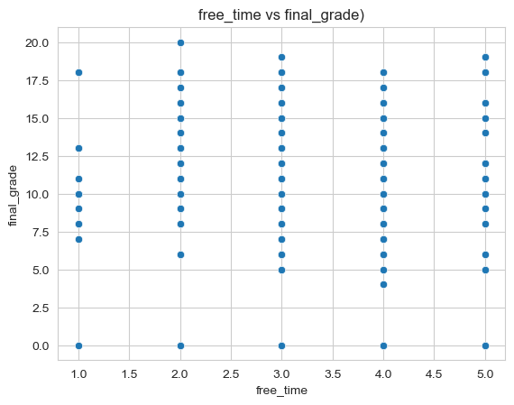

```python
sns.scatterplot(x='free_time', y='final_grade', data=df)
plt.title('free_time vs final_grade)')
plt.show()
```

### Research Question 2 (Does drinking alcohol on weekdays affects the grades?)

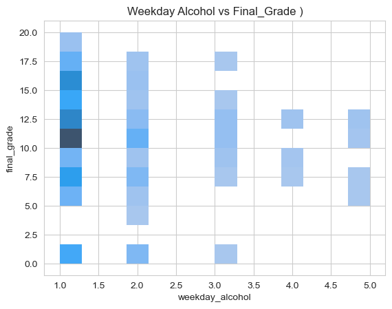

```python
sns.histplot(x='weekday_alcohol', y='final_grade', data=df)
plt.title('Weekday Alcohol vs Final_Grade )')
plt.show()
```

```python
weekday_alcohol_grade = df.groupby('weekday_alcohol')['final_grade'].describe()
print(study_grade_stats)
```

[output not shown]

### Research Question 3 (Do students with internet access at home achieve higher grades?)

```python
internet_access_grade = df.groupby('internet_access')['final_grade'].describe()
print(study_grade_stats)
```

[output not shown]

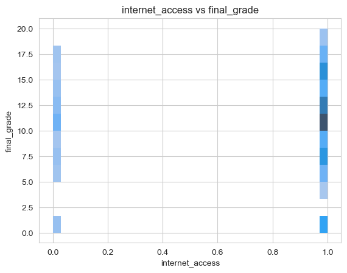

```python
sns.histplot(x='internet_access', y='final_grade', data=df)
plt.title('internet_access vs final_grade')
plt.show()
```